```python
from adsy.display import extended_styles
import statsmodels.api as sm
%matplotlib inline
```

```python
extended_styles()
```

Toggle Input

# Learning in a Dumb Way : More data exploration and an initial NN

This is the result of an initial data exploration. Here I do not suggest any methods of fixing, I just point out the problems and then we can collectively decide what needs to be fixed and how to acheive that. Click the toggle input button (above) to hide all of the code.

```python
import pandas as pd
import numpy as np
from matplotlib import pyplot as plt
import copy
#Uncomment to read in data again
rawdata  = pd.read_csv("./allziptot.csv") # Load data
columns = list(rawdata.columns) # Rename Columns (3lines)
columns[0]="zipcode"
rawdata.columns = columns
rawdata.index.name ="row"
rawdata.drop(54663, inplace=True) # Drop the duplicate
rawdata.drop("zipstr", axis=1, inplace=True)
indexed_data = rawdata.set_index(["year", "zipcode"]) # Reindex by year and zip
yearpan = indexed_data.to_panel() # Change to a panel dataframe
datainv = rawdata.set_index(["zipcode", "year"]) # Another panel by zip and year
zippan = datainv.to_panel()
```

```python
def plot_employment_at_zip(zipcode, data=rawdata):
    zipdata = data[data["zipcode"]==zipcode]
    ax = zipdata.plot("year", "emp", legend=True, label="Employment in zipcode " +str(zipcode))
    #plt.legend("Employment")
    return ax

def plot_pctchg_at_zip(zipcode, data=rawdatapchg):
    usedata = data[data["zipcode"]==zipcode]
    ax = usedata.plot("year", "pctchg", legend=True, label="Employment in zipcode " +str(zipcode))
    return ax

def check_dup_ix(data=rawdata):
    for year in data.year.unique():
        yeardata = data[data.year==year]
        print "The number of zipcodes are ", len(yeardata.zip), " and the number of unique zipcodes are ", len(yeardata.zip.unique())
    return "Done"

def dupzip95(data):
    d95 = data[data.year==1995]
    counted = []
    for zcode in d95.zipcode:
        if zcode not in counted:
            counted.append(zcode)
        else:
            print zcode

def emp_hist_by_year(pctchd):
    fig, axes = plt.subplots(4,5)
    for ix, year in enumerate(np.arange(1994, 2013)):
        data = pctchd.major_xs(year).emp.values
        print ix/4, ix%5
        ax = axes[(ix)/5][ix%5]
        ax.hist(data, bins=np.arange(-.5,.5,.01))
        ax.set_title(year)
    fig.tight_layout()
    return fig, ax

def get_pctchg_by_zip(data, zipcode):
    return data["pctchg"][data.zipcode==zipcode]

def get_autocorr_dist(datain, maxlag=3):
    data = datain.dropna()
    acors = []
    zipcodes = np.unique(datain.zipcode.values)
    for z in zipcodes:
        try:
            series = get_pctchg_by_zip(data, z).values
            if len(series) > maxlag:
                acorr= sm.tsa.acf(series, nlags=maxlag)
                acors.append(acorr)
        except Exception:
            print z
            return "Failure"
    return acors

def zips_with_zeros(data):
    """
    data : DataFrame (not Panel)

    Returns list of zipcodes that contain at least 1 zero
    """
    grouped=data.groupby("zipcode")
    zerozips = []
    smallzips = 0
    for name, group in grouped:
         if min(group.emp)==0:
            zerozips.append(name)
            if max(group.emp) < 500:
                smallzips +=1
    return zerozips, smallzips

def build_dataset_for_network(indata, lag=2):
    """
    Here we need to put the dataset into a form that the NN can handle.
    For this function, we only use time-series of length 19.  We will have:

    num_zipcodes * 16 observations
    """
    data = indata.drop("emp", axis=1)
    grouped = data.groupby("zipcode")
    nndata = []
    for name, group in grouped:
        for year in np.arange(1998,2013):
            nndata.append(group[(group.year<year)& (group.year>year-4)].pctchg.values)
    return nndata
```

### "Stupid" fix 1: Dropping Missing Values

Recall, Approximately 17% of the values are 0. This can be either because missing data is coded as 0's. **For now** I am just going to drop those. In the future, there are several ways to better address this issue. They include:

- Linear Interpolation (bad)
- Interpolating by MSA or county data (bad)
- Parametric Spatial Model (ok)
- Preprocessing Spatial Neural Network (good)
- Simultaneous interpolation/forecasting Spatial Neural Network (good)

But before we get fancy, let's just be dumb and drop missing data

```python
zerozips, smallzips = zips_with_zeros(rawdata)
```

```python
print "Need to drop " + str(100 * float(len(zerozips)) / len(np.unique(rawdata.zipcode))) +r"%", "of zipcodes"
```

```
Need to drop 46.9880365939% of zipcodes
```

Yikes! This is worse than I thought! For now, we will proceed with the NN forecasting using non-zero zip-codes. It is clear to me now that the biggest issue is not including spatial dependencies nor is is includeing data on multiple time scales. Instead, it is intelligently dealing with missing data. However of the approximately 20000 zipcodes we dropped, about 16,000 (80%) of them *never* had more than 500 employees in any year. This implies that many of the zipcodes we dropped are relatively insignificant (no more than 5% of the total labor force). There are also zipcodes where the "hard-coded" data does not include data for all years. We are going to drop these too.

```python
mask = rawdata['zipcode'].isin(zerozips)
todrop = mask.index[mask==True]
rawdatapchg = rawdata.drop(todrop) # Remove zipcodes with 0's
grouped = rawdatapchg.groupby("zipcode")
yearcounts = grouped.apply(lambda x: len(x.year))
zips_w_missing_yr = yearcounts[yearcounts<19].index
mask = rawdatapchg['zipcode'].isin(zips_w_missing_yr)
todrop = mask.index[mask==True]
rawdatapchg.drop(todrop, inplace=True);
```

In general, neural networks "prefer" normalized data. Therefore, instead of trying to pick total employment, we will try to predict percent change. Note that we lose some information here because we lose the size of the zipcode, which may impact percent change. Let's ignore it for now but I'll show its impact later.

```python
zipgroup = rawdatapchg.groupby("zipcode")
w = zipgroup.emp.pct_change()
vals = np.copy(w.loc[:].values);
rawdatapchg["pctchg"] = vals;
rawdatapchg.dropna(inplace=True);
```

### "Stupid" Input Generation : Examine the autocorrelation to "optimally" determine sample size.

Since we have 18 years of data, one way to train a neural network would be to give it 17 previous years and ask it to predict the 18th. However, this gives us a number of trainning samples equal to the number of zipcodes. Also, it is unlikely that the percent change from 1994 to 1995 affects the percent change from 2011 to 2012. If we can determine when the autocorrelation goes to 0, we can increase our sample size.

```python
acordist = get_autocorr_dist(rawdatapchg, maxlag=6) # Sample Auto-correlation for up to 6 lags
acordist = np.asarray(acordist)
```

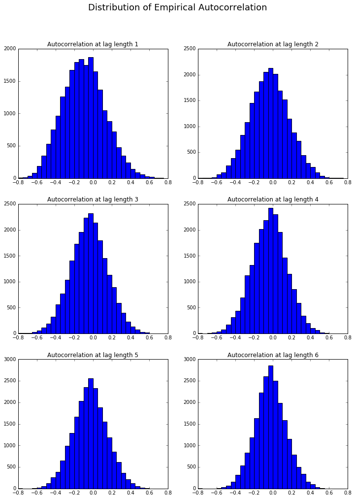

```python
fig, ax = plt.subplots(3,2)
fig.set_figheight(16)
fig.set_figwidth(12)
lag=1
for i in range(3):
    for j in range(2):
        ax[i][j].hist(acordist[:,lag], bins=np.arange(-.8,.8,.05))
        ax[i][j].set_title("Autocorrelation at lag length " + str(lag))
        lag += 1
fig.suptitle("Distribution of Empirical Autocorrelation", fontsize=18);
```

Visually, it looks like there is a negative autocorrelation for the 1 period lag but after that, the autocorrelations appear to be distributed normally and centered around zero. The high variance is due to very small time scales in which to calculate the auto-correlation. Therefore, I am making the executive decision to run this first neural network using 2 lags (of course we will check this for robustness later).

So finally we can build the model. In the simples case, we assume that:

\begin{equation} y_{t} = f(y_{t-1}, y_{t-2}) \end{equation}

Note that in this case, there is no dependence on the zipcode! Therefore, we are implicitly assuming that the DGP is the same for all $i$ and only depends on time lags. This is of course, very bad. The linear model specifies:

\begin{equation} y_{t} = c + \rho_1 y_{t-1} + \rho_2 y_{t-2} \end{equation}

We now estimate this model on the full datset

```python
nndata = build_dataset_for_network(rawdatapchg)
nndata = np.asarray(nndata)
yt = nndata[:,2]
X = nndata[:,:2]
X=sm.add_constant(X)
model=sm.OLS(yt,X)
fitted=model.fit()
```

While we can examine parameters, significance, $R^2$ and the such, we are (for the moment) only interested in forecasting. So let's look at the standard measure of forecasing, the root mean squared error

```python
print "The root MSE is ", fitted.mse_resid**.5
```

```
The root MSE is  0.264764550353
```

This is --- for lack of better words --- terrible. It says that on average, our forecast is off by 25%. Not that we are 25% away from the truth but our forecast for the change in employment is 25% off. (In other words, we predict employment increases by 50% but it actually only increases by 25%). This is not surpising since, as I said all along, this model is stupid/dumb. However, it will be interesing to see how the Neural Network compares in even this very dumb setup.

```python
data95 = rawdatapchg[rawdatapchg["year"]==1995]
smallzips = data95.zipcode[data95.emp<1000]
mask = rawdatapchg['zipcode'].isin(smallzips)
todrop = mask.index[mask==True]
rawdata1k = rawdatapchg.drop(todrop);
```

```python
nndata1k = build_dataset_for_network(rawdata1k)
nndata1k = np.asarray(nndata1k)
yt1k = nndata1k[:,2]
X1k = nndata1k[:,:2]
X1k=sm.add_constant(X1k)
model=sm.OLS(yt1k,X1k)
fitted=model.fit()
```

```python
print "The root MSE with 'large' zipcodes is ", fitted.mse_resid**.5
```

```
The root MSE with 'large' zipcodes is  0.132123505738
```

Just by excluding small zipcodes, we essentially cut the root mse in half. I think this is a good baseline for an initial neural network.

### The Neural Network

In our initial Neural Network, we will use a feed-forward network with one hidden layer and a hyperbolic tangent activation function. The loss criteria is (root) mean squared error.

```python
loss = "mse"
holdout = .2
```

```python
from keras.models import Sequential
from keras.layers import Dense
testing_ix = np.random.choice(range(len(X1k)), size = int(holdout * len(X1k)), replace=False)
Xtest = X1k[testing_ix, 1:]
ytest = yt1k[testing_ix]
training_ix = np.delete(np.arange(len(X1k)), testing_ix)
Xtrain = X1k[training_ix, 1: ]
ytrain = yt1k[training_ix]
```

```python
nn = Sequential()
nn.add(Dense(2, input_dim=2, init='uniform', activation='tanh'))
nn.add(Dense(1, init='uniform', activation='tanh'))
nn.compile(loss=loss, optimizer='rmsprop')
```

```python
nn.fit(Xtrain, ytrain, batch_size=32)
```

```
<keras.callbacks.History at 0x7f282a682550>
```

```python
print "The MSE under the Neural Network is ", nn.evaluate(Xtrain, ytrain, verbose=0)**.5
```

```
The MSE under the Neural Network is  0.129380539196
```

# Improvements

There are many improvements we can make. Succinctly, they are:

- Interpolating missing values
- Including zipcodes with a small number of employees
- Include Spatial Relationships
- Include "macro" variables (MSA, County and other employment data)

I would like to tackle these in **reverse** order.

# Questions

- Is the employment data only for full time employees?
- There are some zip-code with errors where some years are set to $0$ (see zipcode 20010). There are also zipcodes in the main data set where there are not observations for certain years. What's the deal there?